# Temporal-Difference Methods

### Part 3: TD Control: Expected Sarsa

In this section, you will write your own implementation of the Expected Sarsa control algorithm.

Your algorithm has four arguments:

- `env`: This is an instance of an OpenAI Gym environment.
- `num_episodes`: This is the number of episodes that are generated through agent-environment interaction.
- `alpha`: This is the step-size parameter for the update step.
- `gamma`: This is the discount rate. It must be a value between 0 and 1, inclusive (default value: `1`).

Please complete the function in the code cell below.

(*Feel free to define additional functions to help you to organize your code.*)

```python
def get_expected_sarsa(state, action, reward, next_state, Q ,done, alpha, gamma,epsilon):
    if done:
        q=Q[state][action]+alpha*(reward+0-Q[state][action])
    else:
        max_val = max(Q[next_state])*(1-epsilon+(epsilon/len(Q[state]))) #Weight the largest value with 1-e+e/|A|
        vals=np.sum(Q[next_state])*epsilon/len(Q[next_state]) + max_val  #Weight all the values by e/|A| and add them to weighted max value to return expected value
        q=Q[state][action]+alpha*(reward+gamma*vals-Q[state][action]) #get the updated value for Q[state][action] and return
    return q
```

```python
def expected_sarsa(env, num_episodes, alpha, gamma=1.0):
    # initialize action-value function (empty dictionary of arrays)
    Q=defaultdict(lambda: np.zeros(env.action_space.n))
    policy={}
    J=[]
    total_rewards=[]
    epsilon_val=[]
    # initialize performance monitor
    for i in range(num_episodes):
        j=0
        rew=0
        epsilon=0.005
        states=[] #Troubleshooting
        state=env.reset()
        if state in policy:
            action=get_action(state,policy, epsilon)
        else:
            action=env.action_space.sample()
        while True: # for each timestep of the episode
            next_state,reward,done,info=env.step(action)
            next_action = get_action(next_state, policy,epsilon) if next_state in policy.keys() else env.action_space.sample()
            Q[state][action]=get_expected_sarsa(state, action, reward, next_state, Q, done, alpha, gamma,epsilon)
            update_policy(state,Q,policy)
            states.append((state,action,reward,next_state))
            j+=1
            rew+=reward
            if done:
                break
            else:
                state=next_state
                action=next_action
        epsilon_val.append(epsilon)
        J.append(j)
        total_rewards.append(rew)
    return (Q,J,total_rewards,policy,num_episodes,epsilon_val)
```

Use the next code cell to visualize the *estimated* optimal policy and the corresponding state-value function.

```
Estimated Optimal Policy (UP = 0, RIGHT = 1, DOWN = 2, LEFT = 3, N/A = -1):
[[ 2  1  1  3  2  3  1  1  1  2  2  2]
 [ 0  0  2  1  0  2  1  1  2  2  2  2]
 [ 1  1  1  1  1  1  1  1  1  1  1  2]
 [ 0 -1 -1 -1 -1 -1 -1 -1 -1 -1 -1 -1]]
```

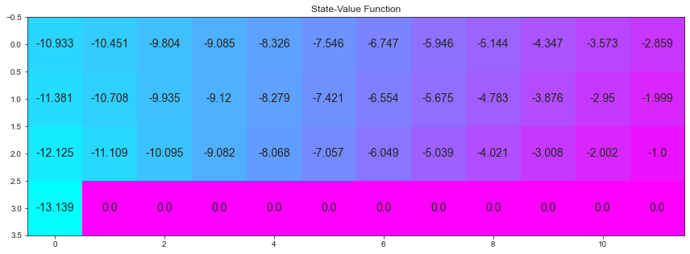

```
Estimated Optimal Policy (UP = 0, RIGHT = 1, DOWN = 2, LEFT = 3, N/A = -1):
[[ 3  1  1  1  1  0  1  2  2  1  0  2]
 [ 1  1  1  3  1  1  2  2  2  1  2  2]
 [ 1  1  1  1  1  1  1  1  1  1  1  2]
 [ 0 -1 -1 -1 -1 -1 -1 -1 -1 -1 -1 -1]]
```

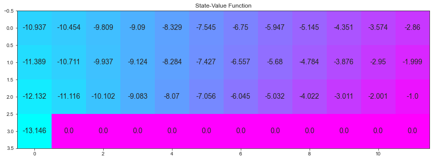

```
Estimated Optimal Policy (UP = 0, RIGHT = 1, DOWN = 2, LEFT = 3, N/A = -1):
[[ 1  3  1  1  1  3  1  2  2  1  1  3]
 [ 1  1  1  3  1  1  1  2  1  1  1  2]
 [ 1  1  1  1  1  1  1  1  1  1  1  2]
 [ 0 -1 -1 -1 -1 -1 -1 -1 -1 -1 -1 -1]]
```

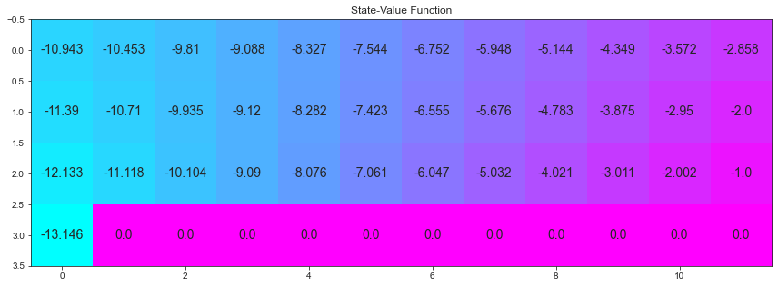

```
Estimated Optimal Policy (UP = 0, RIGHT = 1, DOWN = 2, LEFT = 3, N/A = -1):
[[ 1  1  0  1  1  1  0  0  0  1  1  3]
 [ 1  2  1  0  1  2  1  1  0  1  2  2]
 [ 1  1  1  1  1  1  1  1  1  1  1  2]
 [ 0 -1 -1 -1 -1 -1 -1 -1 -1 -1 -1 -1]]
```

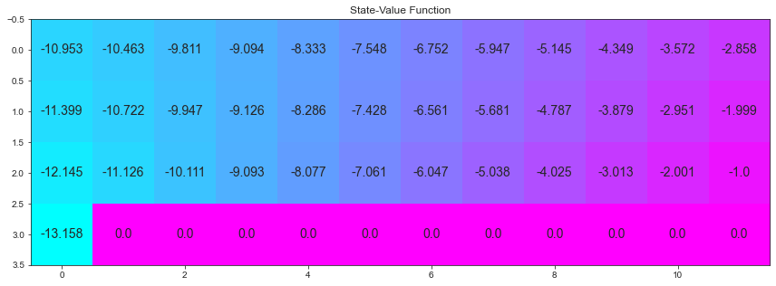

```
Estimated Optimal Policy (UP = 0, RIGHT = 1, DOWN = 2, LEFT = 3, N/A = -1):
[[ 0  1  2  2  1  1  1  1  1  2  2  3]
 [ 1  1  0  0  2  2  2  1  1  2  2  2]
 [ 1  1  1  1  1  1  1  1  1  1  1  2]
 [ 0 -1 -1 -1 -1 -1 -1 -1 -1 -1 -1 -1]]
```

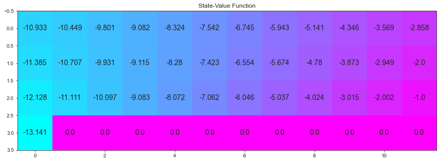

```
Estimated Optimal Policy (UP = 0, RIGHT = 1, DOWN = 2, LEFT = 3, N/A = -1):
[[ 1  3  3  0  1  1  1  1  1  1  2  2]
 [ 1  1  1  3  1  1  2  0  2  2  1  2]
 [ 1  1  1  1  1  1  1  1  1  1  1  2]
 [ 0 -1 -1 -1 -1 -1 -1 -1 -1 -1 -1 -1]]
```

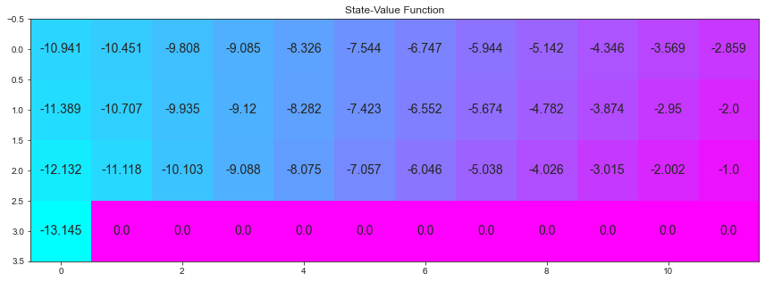

```
Estimated Optimal Policy (UP = 0, RIGHT = 1, DOWN = 2, LEFT = 3, N/A = -1):
[[ 2  1  1  1  1  1  2  1  1  0  2  3]
 [ 1  1  3  0  1  2  1  1  1  2  1  2]
 [ 1  1  1  1  1  1  1  1  1  1  1  2]
 [ 0 -1 -1 -1 -1 -1 -1 -1 -1 -1 -1 -1]]
```

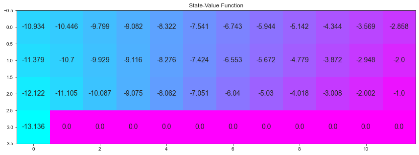

```
Estimated Optimal Policy (UP = 0, RIGHT = 1, DOWN = 2, LEFT = 3, N/A = -1):
[[ 3  2  3  0  1  1  1  1  1  2  1  3]
 [ 1  1  0  1  1  1  1  1  1  1  1  2]
 [ 1  1  1  1  1  1  1  1  1  1  1  2]
 [ 0 -1 -1 -1 -1 -1 -1 -1 -1 -1 -1 -1]]
```

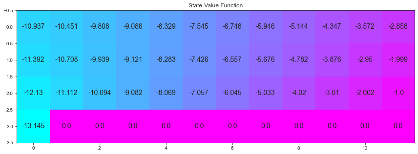

```
Estimated Optimal Policy (UP = 0, RIGHT = 1, DOWN = 2, LEFT = 3, N/A = -1):
[[ 0  3  1  3  1  2  1  1  3  1  2  3]
 [ 1  3  1  1  1  1  1  1  1  1  2  2]
 [ 1  1  1  1  1  1  1  1  1  1  1  2]
 [ 0 -1 -1 -1 -1 -1 -1 -1 -1 -1 -1 -1]]
```

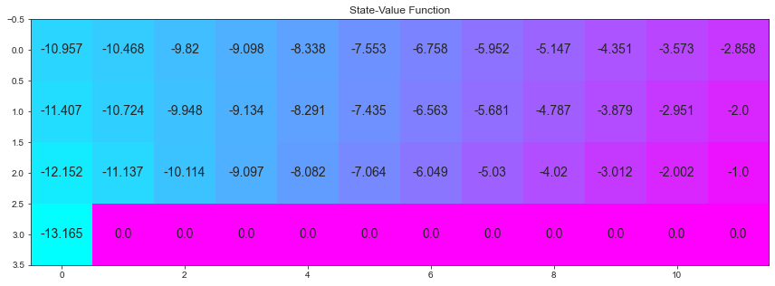

```
Estimated Optimal Policy (UP = 0, RIGHT = 1, DOWN = 2, LEFT = 3, N/A = -1):
[[ 3  1  1  2  2  1  1  2  3  1  1  2]
 [ 0  1  3  1  0  1  1  1  3  3  1  2]
 [ 1  1  1  1  1  1  1  1  1  1  1  2]
 [ 0 -1 -1 -1 -1 -1 -1 -1 -1 -1 -1 -1]]
```

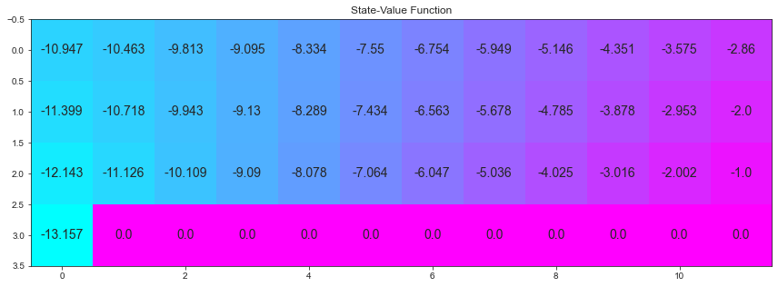

```python
attempts_esarsa=[]
for _ in range(10):
    Q_esarsa, J_sarsa, total_reward,policy, n_epsiodes,epsilon_val = expected_sarsa(env, 5000, .01)
    attempts_esarsa.append((Q_esarsa, J_sarsa, total_reward,policy, n_epsiodes))

# print the estimated optimal policy
for a in attempts_esarsa:
    Q_sarsa=a[0]
    policy_sarsa = np.array([np.argmax(Q_sarsa[key]) if key in Q_sarsa else -1 for key in np.arange(48)]).reshape(4,12)
    print("\nEstimated Optimal Policy (UP = 0, RIGHT = 1, DOWN = 2, LEFT = 3, N/A = -1):")
    print(policy_sarsa)

    # plot the estimated optimal state-value function
    V_sarsa = ([np.max(Q_sarsa[key]) if key in Q_sarsa else 0 for key in np.arange(48)])
    plot_values(V_sarsa)
```

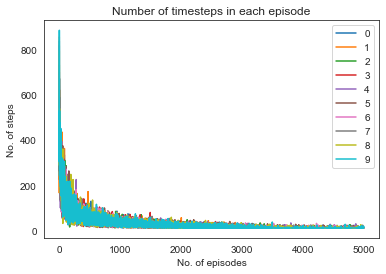

```python
for i in range(len(attempts_esarsa)):
    steps_arr=attempts_esarsa[i][1]
    n_episodes=attempts_esarsa[i][4]
    plt.plot(range(n_episodes),steps_arr)
    plt.xlabel('No. of episodes')
    plt.ylabel('No. of steps')
    plt.title('Number of timesteps in each episode')
    plt.legend(np.arange(i+1))
plt.show()
```

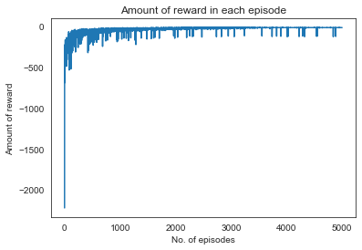

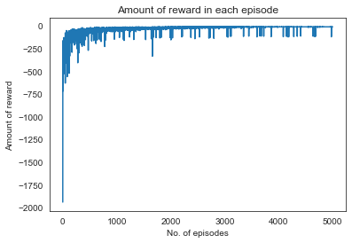

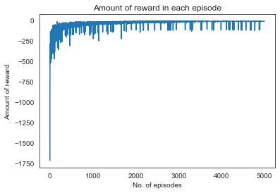

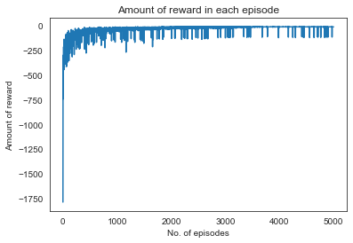

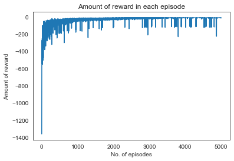

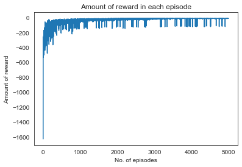

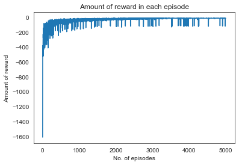

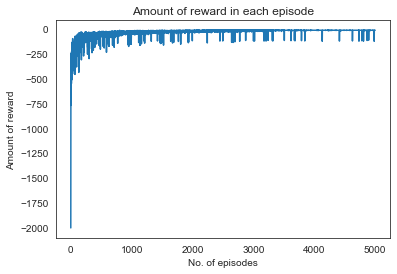

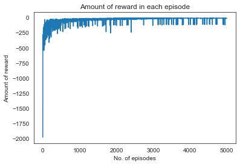

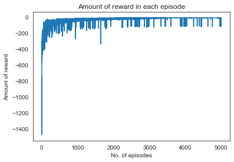

```python
for i in range(len(attempts_esarsa)):
    reward=attempts_esarsa[i][2]
    n_episodes=attempts_esarsa[i][4]
    plt.plot(range(5000),reward)
    plt.xlabel('No. of episodes')
    plt.ylabel('Amount of reward')
    plt.title('Amount of reward in each episode')
    plt.show()
```